# Exercise Prediction

Siyi Gu

10/7/2020

## Introduction

This is a prediction assignment for the Coursera practical machine learning course project. The goal is to use data from accelerometers on the belt, forearm, arm, and dumbell of 6 participants, whom were asked to perform barbell lifts correctly and incorrectly in 5 different ways, and to predict the manner in which they did the exercise. The analysis will build different models from the training data set and assess their performance; one model will be selected in the end as the best.

## Getting and cleaning the data

- Load the data sets and necessary libraries:

```r
library(caret)
library(randomForest)
library(gbm)
```

```r
library(ggplot2)
library(dplyr)
training<-read.csv("https://d396qusza40orc.cloudfront.net/predmachlearn/pml-training.csv")
testing<-read.csv("https://d396qusza40orc.cloudfront.net/predmachlearn/pml-testing.csv")
dim(training)
```

```
## [1] 19622   160
```

```r
dim(testing)
```

```
## [1]  20 160
```

- Remove some variables that have NA values and near zero values in them:

```r
training<-training[,colSums(is.na(training))==0]
NZV<-nearZeroVar(training)
training<-training[,-NZV]
```

- The first few columns are time and user information which is not likely to affect prediction, remove these columns:

```r
training<-training[,-c(1:6)]
dim(training)
```

```
## [1] 19622    53
```

- The final training data set has 53 variables left, split the training data set further into training and cross validation set:

```r
set.seed(345)
inTrain<-createDataPartition(training$classe,p=0.7,list=F)
tr<-training[inTrain,]
cv<-training[-inTrain,]
```

## Building models

- Build model with trees:

```r
set.seed(345)
modtr<-train(classe~.,data=tr,method="rpart")
print(modtr)
```

```
## CART
##
## 13737 samples
##    52 predictor
##     5 classes: 'A', 'B', 'C', 'D', 'E'
##
## No pre-processing
## Resampling: Bootstrapped (25 reps)
## Summary of sample sizes: 13737, 13737, 13737, 13737, 13737, 13737, ...
## Resampling results across tuning parameters:
##
##   cp          Accuracy   Kappa
##   0.03366901  0.5145686  0.36813261
##   0.06008205  0.4323119  0.23601421
##   0.11504425  0.3172041  0.04949994
##
## Accuracy was used to select the optimal model using the largest value.
## The final value used for the model was cp = 0.03366901.
```

```r
library(rattle)
```

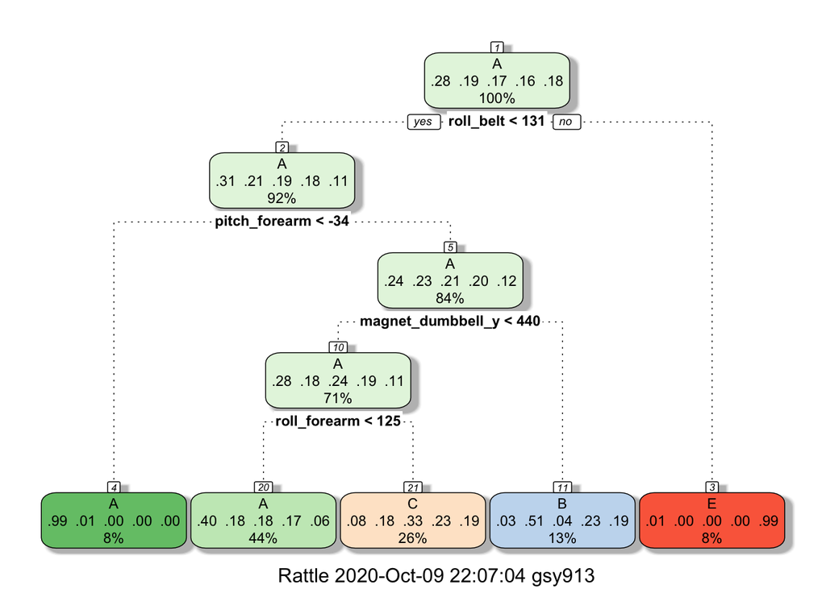

```r
fancyRpartPlot(modtr$finalModel)
```

- Build model with random forest:

```r
set.seed(345)
modrf<-train(classe~.,method="rf",data=tr)
print(modrf)
```

```
## Random Forest
##
## 13737 samples
##    52 predictor
##     5 classes: 'A', 'B', 'C', 'D', 'E'
##
## No pre-processing
## Resampling: Bootstrapped (25 reps)
## Summary of sample sizes: 13737, 13737, 13737, 13737, 13737, 13737, ...
## Resampling results across tuning parameters:
##
##   mtry  Accuracy   Kappa
##    2    0.9885133  0.9854637
##   27    0.9888148  0.9858463
##   52    0.9785198  0.9728181
##
## Accuracy was used to select the optimal model using the largest value.
## The final value used for the model was mtry = 27.
```

- Build model with boosting:

```r
set.seed(345)
modgbm<-train(classe~.,data=tr, method="gbm",verbose=FALSE)
print(modgbm)
```

```
## Stochastic Gradient Boosting
##
## 13737 samples
##    52 predictor
##     5 classes: 'A', 'B', 'C', 'D', 'E'
##
## No pre-processing
## Resampling: Bootstrapped (25 reps)
## Summary of sample sizes: 13737, 13737, 13737, 13737, 13737, 13737, ...
## Resampling results across tuning parameters:
##
##   interaction.depth  n.trees  Accuracy   Kappa
##   1                   50      0.7517786  0.6851229
##   1                  100      0.8167532  0.7679445
##   1                  150      0.8495035  0.8094643
##   2                   50      0.8522946  0.8127908
##   2                  100      0.9035810  0.8779222
##   2                  150      0.9285514  0.9095612
##   3                   50      0.8930212  0.8645098
##   3                  100      0.9382266  0.9218060
##   3                  150      0.9573825  0.9460645
##
## Tuning parameter 'shrinkage' was held constant at a value of 0.1
##
## Tuning parameter 'n.minobsinnode' was held constant at a value of 10
## Accuracy was used to select the optimal model using the largest value.
## The final values used for the model were n.trees = 150, interaction.depth =
##  3, shrinkage = 0.1 and n.minobsinnode = 10.
```

- Based on the in-sample accuracy the random forest model works the best.

## Testing

- Testing all three models with the cross validation test set, first with decision tree:

```r
cv$classe<-factor(cv$classe)
confusionMatrix(predict(modtr,cv),cv$classe)
```

```
## Confusion Matrix and Statistics
##
##           Reference
## Prediction    A    B    C    D    E
##          A 1533  481  476  442  146
##          B   19  376   36  164  156
##          C  118  282  514  358  290
##          D    0    0    0    0    0
##          E    4    0    0    0  490
##
## Overall Statistics
##
##                Accuracy : 0.495
##                  95% CI : (0.4821, 0.5078)
##     No Information Rate : 0.2845
##     P-Value [Acc > NIR] : < 2.2e-16
##
##                   Kappa : 0.3397
##
##  Mcnemar's Test P-Value : NA
##
## Statistics by Class:
##
##                      Class: A Class: B Class: C Class: D Class: E
## Sensitivity            0.9158  0.33011  0.50097   0.0000  0.45287
## Specificity            0.6331  0.92099  0.78432   1.0000  0.99917
## Pos Pred Value         0.4981  0.50067  0.32907      NaN  0.99190
## Neg Pred Value         0.9498  0.85138  0.88156   0.8362  0.89019
## Prevalence             0.2845  0.19354  0.17434   0.1638  0.18386
## Detection Rate         0.2605  0.06389  0.08734   0.0000  0.08326
## Detection Prevalence   0.5230  0.12761  0.26542   0.0000  0.08394
## Balanced Accuracy      0.7744  0.62555  0.64265   0.5000  0.72602
```

- With random forest:

```r
confusionMatrix(predict(modrf,cv),cv$classe)
```

```
## Confusion Matrix and Statistics
##
##           Reference
## Prediction    A    B    C    D    E
##          A 1673    8    0    1    0
##          B    1 1127    3    1    0
##          C    0    3 1018    5    0
##          D    0    1    5  957    4
##          E    0    0    0    0 1078
##
## Overall Statistics
##
##                Accuracy : 0.9946
##                  95% CI : (0.9923, 0.9963)
##     No Information Rate : 0.2845
##     P-Value [Acc > NIR] : < 2.2e-16
##
##                   Kappa : 0.9931
##
##  Mcnemar's Test P-Value : NA
##
## Statistics by Class:
##
##                      Class: A Class: B Class: C Class: D Class: E
## Sensitivity            0.9994   0.9895   0.9922   0.9927   0.9963
## Specificity            0.9979   0.9989   0.9984   0.9980   1.0000
## Pos Pred Value         0.9946   0.9956   0.9922   0.9897   1.0000
## Neg Pred Value         0.9998   0.9975   0.9984   0.9986   0.9992
## Prevalence             0.2845   0.1935   0.1743   0.1638   0.1839
## Detection Rate         0.2843   0.1915   0.1730   0.1626   0.1832
## Detection Prevalence   0.2858   0.1924   0.1743   0.1643   0.1832
## Balanced Accuracy      0.9986   0.9942   0.9953   0.9954   0.9982
```

- With boosting:

```r
confusionMatrix(predict(modgbm,cv),cv$classe)
```

```
## Confusion Matrix and Statistics
##
##           Reference
## Prediction    A    B    C    D    E
##          A 1644   42    0    2    0
##          B   18 1055   29    2   13
##          C    6   40  984   17    4
##          D    3    1   10  935   17
##          E    3    1    3    8 1048
##
## Overall Statistics
##
##                Accuracy : 0.9628
##                  95% CI : (0.9576, 0.9675)
##     No Information Rate : 0.2845
##     P-Value [Acc > NIR] : < 2.2e-16
##
##                   Kappa : 0.9529
##
##  Mcnemar's Test P-Value : 7.269e-05
##
## Statistics by Class:
##
##                      Class: A Class: B Class: C Class: D Class: E
## Sensitivity            0.9821   0.9263   0.9591   0.9699   0.9686
## Specificity            0.9896   0.9869   0.9862   0.9937   0.9969
## Pos Pred Value         0.9739   0.9445   0.9363   0.9679   0.9859
## Neg Pred Value         0.9929   0.9824   0.9913   0.9941   0.9929
## Prevalence             0.2845   0.1935   0.1743   0.1638   0.1839
## Detection Rate         0.2794   0.1793   0.1672   0.1589   0.1781
## Detection Prevalence   0.2868   0.1898   0.1786   0.1641   0.1806
## Balanced Accuracy      0.9858   0.9566   0.9726   0.9818   0.9827
```

- Based on the out-of-sample error rate, the random forest model works the best.

## Conclusions

- Based on the performance of the models, the final model selected is the random forest model. The prediction for the test set is as follows:

```r
predict(modrf,testing)
```

```
##  [1] B A B A A E D B A A B C B A E E A B B B
## Levels: A B C D E
```